#### Machine Learning - Course Work 1 (24.1F)

#### Index: COHNDDS24.1F - 012

# **Implementation of Machine Learning to Determine the Best Employees**

#### **Introduction**

In businesses, finding and keeping the best employees is key to success. This project aims to build a system that predicts which employees are the best based on their performance and other factors. We used a dataset with information about employees and tested several machine learning methods, including Decision Trees, Random Forest, K-Nearest Neighbors (KNN), and XGBoost. By comparing these methods, we want to find out which one works best for predicting employee performance.

#### Research Design

1. Preprocessing
2. missing Values Imputation
3. Classification
4. Evaluation
5. Conclusion

## **Data Preprocessing**

#### Importing Necessary Libraries

```python
import os
import numpy as np
import warnings
warnings.filterwarnings("ignore")
import pandas as pd
from matplotlib import pyplot as plt
import seaborn as sns
```

```python
from sklearn.ensemble import RandomForestClassifier
from sklearn.metrics import mean_squared_error, r2_score
from sklearn.tree import DecisionTreeClassifier
from sklearn.model_selection import train_test_split
from sklearn.metrics import accuracy_score
```

```python
from sklearn.model_selection import KFold
from sklearn.model_selection import cross_val_score
from sklearn.neighbors import KNeighborsClassifier
from xgboost import XGBClassifier
from sklearn.metrics import accuracy_score, classification_report, confusion_matrix
```

#### Loading Dataset

```python
df = pd.read_csv("HR Employee data.csv")
df.head()
```

|  | EmployeeID | JoiningYear | Age | BusinessTravel | DailyRate | Department | DistanceFromHome | EducationField | EmployeeCount | EmployeeNumber | ... | YearsAtCompany | YearsInCurrentRole | YearsSinceLastPromotion | YearsWithCurrManager | Attrition | LeavingYear | Reason | RelievingStatus | office_code | JobLevel_updated |
| --- | --- | --- | --- | --- | --- | --- | --- | --- | --- | --- | --- | --- | --- | --- | --- | --- | --- | --- | --- | --- | --- |
| 0 | 100000 | 2005 | 57 | Travel_Rarely | 164 | Corporate Functions | 22 | Doctorate | 1 | 217 | ... | 14 | 4 | 5 | 3 | Yes | 2019.0 | long hours | Voluntary | BOS | L7 |
| 1 | 100001 | 2006 | 52 | Travel_Rarely | 265 | Corporate Functions | 19 | Doctorate | 1 | 519 | ... | 12 | 4 | 5 | 3 | Yes | 2018.0 | medical issues | Voluntary | NYC | L6 |
| 2 | 100002 | 2006 | 53 | Travel_Rarely | 607 | Corporate Functions | 2 | Doctorate | 1 | 1572 | ... | 12 | 3 | 1 | 4 | Yes | 2018.0 | retiring | Voluntary | OTT | L6 |
| 3 | 100003 | 2006 | 54 | Travel_Rarely | 215 | Corporate Functions | 19 | Diploma | 1 | 309 | ... | 13 | 4 | 5 | 3 | Yes | 2019.0 | career change | Voluntary | NYC | L7 |
| 4 | 100004 | 2007 | 57 | Travel_Rarely | 285 | Marketing | 2 | Diploma | 1 | 828 | ... | 11 | 5 | 5 | 3 | Yes | 2018.0 | retiring | Voluntary | CAL | L5 |

5 rows × 39 columns

#### Checking Columns and Dimention of the dataset

```python
#Checking Columns
df.columns
```

```
Index(['EmployeeID', 'JoiningYear', 'Age', 'BusinessTravel', 'DailyRate',
       'Department', 'DistanceFromHome', 'EducationField', 'EmployeeCount',
       'EmployeeNumber', 'EnvironmentSatisfaction', 'Gender', 'HourlyRate',
       'JobInvolvement', 'JobSatisfaction', 'MaritalStatus', 'MonthlyIncome',
       'MonthlyRate', 'NumCompaniesWorked', 'Over18', 'OverTime',
       'PercentSalaryHike', 'PerformanceRating', 'RelationshipSatisfaction',
       'StandardHours', 'StockOptionLevel', 'TotalWorkingYears',
       'TrainingTimesLastYear', 'WorkLifeBalance', 'YearsAtCompany',
       'YearsInCurrentRole', 'YearsSinceLastPromotion', 'YearsWithCurrManager',
       'Attrition', 'LeavingYear', 'Reason', 'RelievingStatus', 'office_code',
       'JobLevel_updated'],
      dtype='object')
```

```python
# Dimention of the dataset
df.shape
```

```
(13423, 39)
```

#### Unique Values in Each Column

This loop goes through each column in the data and counts how many different values are in each one. This helps you find columns with categories and understand how varied the data is.

```python
for column in df.columns:
    unique_values = df[column].nunique()
    print(f"Column: {column} ||| Unique Values: {unique_values}")
```

```
Column: EmployeeID ||| Unique Values: 13423
Column: JoiningYear ||| Unique Values: 17
Column: Age ||| Unique Values: 43
Column: BusinessTravel ||| Unique Values: 3
Column: DailyRate ||| Unique Values: 1391
Column: Department ||| Unique Values: 6
Column: DistanceFromHome ||| Unique Values: 29
Column: EducationField ||| Unique Values: 4
Column: EmployeeCount ||| Unique Values: 1
Column: EmployeeNumber ||| Unique Values: 2059
Column: EnvironmentSatisfaction ||| Unique Values: 4
Column: Gender ||| Unique Values: 2
Column: HourlyRate ||| Unique Values: 71
Column: JobInvolvement ||| Unique Values: 4
Column: JobSatisfaction ||| Unique Values: 4
Column: MaritalStatus ||| Unique Values: 3
Column: MonthlyIncome ||| Unique Values: 7257
Column: MonthlyRate ||| Unique Values: 10203
Column: NumCompaniesWorked ||| Unique Values: 10
Column: Over18 ||| Unique Values: 1
Column: OverTime ||| Unique Values: 2
Column: PercentSalaryHike ||| Unique Values: 15
Column: PerformanceRating ||| Unique Values: 5
Column: RelationshipSatisfaction ||| Unique Values: 4
Column: StandardHours ||| Unique Values: 1
Column: StockOptionLevel ||| Unique Values: 4
Column: TotalWorkingYears ||| Unique Values: 41
Column: TrainingTimesLastYear ||| Unique Values: 7
Column: WorkLifeBalance ||| Unique Values: 4
Column: YearsAtCompany ||| Unique Values: 15
Column: YearsInCurrentRole ||| Unique Values: 7
Column: YearsSinceLastPromotion ||| Unique Values: 6
Column: YearsWithCurrManager ||| Unique Values: 6
Column: Attrition ||| Unique Values: 2
Column: LeavingYear ||| Unique Values: 5
Column: Reason ||| Unique Values: 15
Column: RelievingStatus ||| Unique Values: 2
Column: office_code ||| Unique Values: 8
Column: JobLevel_updated ||| Unique Values: 7
```

#### Identifying Categorical Variables

Categorical variables are identified and converted into the 'category' data type for easier manipulation.

```python
categorical_variables = ["BusinessTravel", "Department","EducationField", "EnvironmentSatisfaction", "Gender", "JobInvolvement",
                         "JobSatisfaction", "MaritalStatus", "OverTime", "Over18", "PerformanceRating", "RelationshipSatisfaction",
                         "StockOptionLevel", "TrainingTimesLastYear", "WorkLifeBalance",  "Attrition", "LeavingYear", "Reason", "RelievingStatus", "office_code", "JobLevel_updated"]
```

```python
df.dtypes
```

```
EmployeeID                    int64
JoiningYear                   int64
Age                           int64
BusinessTravel               object
DailyRate                     int64
Department                   object
DistanceFromHome              int64
EducationField               object
EmployeeCount                 int64
EmployeeNumber                int64
EnvironmentSatisfaction       int64
Gender                       object
HourlyRate                    int64
JobInvolvement                int64
JobSatisfaction               int64
MaritalStatus                object
MonthlyIncome                 int64
MonthlyRate                   int64
NumCompaniesWorked            int64
Over18                       object
OverTime                     object
PercentSalaryHike             int64
PerformanceRating             int64
RelationshipSatisfaction      int64
StandardHours                 int64
StockOptionLevel              int64
TotalWorkingYears             int64
TrainingTimesLastYear         int64
WorkLifeBalance               int64
YearsAtCompany                int64
YearsInCurrentRole            int64
YearsSinceLastPromotion       int64
YearsWithCurrManager          int64
Attrition                    object
LeavingYear                 float64
Reason                       object
RelievingStatus              object
office_code                  object
JobLevel_updated             object
dtype: object
```

```python
df[categorical_variables] = df[categorical_variables].astype('category')
```

The **EmployeeID** column, which likely serves as a unique identifier, is dropped since it doesn't contribute to the prediction.

```python
df.drop("EmployeeID", axis='columns', inplace=True)
```

#### Statistical Summary of Numerical Variables

We generate a summary of the numerical variables using describe(), which provides statistics like mean, standard deviation, min, and max values. This step is crucial for identifying any potential outliers or inconsistencies in the data.

```python
numerical_variables = ["JoiningYear", "Age", "DailyRate", "DistanceFromHome", "EmployeeCount",
                       "EmployeeNumber", "HourlyRate", "MonthlyIncome", "MonthlyRate", "NumCompaniesWorked",
                       "PercentSalaryHike", "StandardHours", "TotalWorkingYears", "YearsAtCompany",
                       "YearsInCurrentRole", "YearsSinceLastPromotion", "YearsWithCurrManager"]
```

```python
df.describe()
```

|  | JoiningYear | Age | DailyRate | DistanceFromHome | EmployeeCount | EmployeeNumber | HourlyRate | MonthlyIncome | MonthlyRate | NumCompaniesWorked | PercentSalaryHike | StandardHours | TotalWorkingYears | YearsAtCompany | YearsInCurrentRole | YearsSinceLastPromotion | YearsWithCurrManager |
| --- | --- | --- | --- | --- | --- | --- | --- | --- | --- | --- | --- | --- | --- | --- | --- | --- | --- |
| count | 13423.000000 | 13423.000000 | 13423.000000 | 13423.000000 | 13423.0 | 13423.000000 | 13423.000000 | 13423.000000 | 13423.000000 | 13423.000000 | 13423.000000 | 13423.0 | 13423.000000 | 13423.000000 | 13423.000000 | 13423.000000 | 13423.000000 |
| mean | 2018.825300 | 36.159949 | 803.998287 | 8.881472 | 1.0 | 1022.222677 | 65.498622 | 6338.864486 | 14281.290695 | 2.373985 | 14.777546 | 80.0 | 10.572227 | 2.791626 | 1.898979 | 1.396037 | 1.873501 |
| std | 2.005345 | 8.126696 | 356.968483 | 6.844715 | 0.0 | 549.883093 | 17.196420 | 4638.789110 | 7116.133478 | 2.062765 | 3.031840 | 0.0 | 7.246988 | 1.860029 | 1.039347 | 0.818350 | 1.004282 |
| min | 2005.000000 | 18.000000 | 102.000000 | 1.000000 | 1.0 | 1.000000 | 30.000000 | 1009.000000 | 2094.000000 | 0.000000 | 11.000000 | 80.0 | 0.000000 | 1.000000 | 1.000000 | 1.000000 | 1.000000 |
| 25% | 2018.000000 | 30.000000 | 514.500000 | 3.000000 | 1.0 | 554.000000 | 52.000000 | 2776.500000 | 8127.500000 | 1.000000 | 12.000000 | 80.0 | 6.000000 | 2.000000 | 1.000000 | 1.000000 | 1.000000 |
| 50% | 2019.000000 | 35.000000 | 800.000000 | 7.000000 | 1.0 | 1014.000000 | 65.000000 | 4790.000000 | 14273.000000 | 2.000000 | 14.000000 | 80.0 | 9.000000 | 2.000000 | 2.000000 | 1.000000 | 2.000000 |
| 75% | 2020.000000 | 41.000000 | 1106.000000 | 13.000000 | 1.0 | 1493.000000 | 79.000000 | 8147.000000 | 20475.000000 | 4.000000 | 17.000000 | 80.0 | 14.000000 | 3.000000 | 3.000000 | 1.000000 | 3.000000 |
| max | 2021.000000 | 60.000000 | 1499.000000 | 29.000000 | 1.0 | 2068.000000 | 100.000000 | 19999.000000 | 26999.000000 | 9.000000 | 25.000000 | 80.0 | 40.000000 | 15.000000 | 7.000000 | 6.000000 | 6.000000 |

#### Correlation Matrix Heatmap

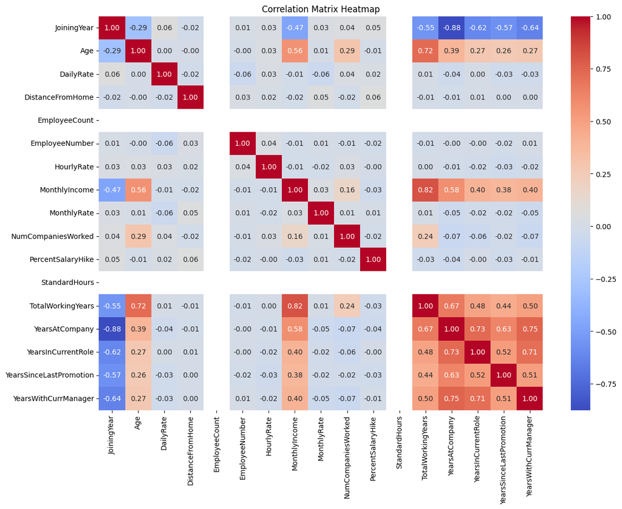

```python
plt.figure(figsize=(14, 10))
corr_matrix = df[numerical_variables].corr()
sns.heatmap(corr_matrix, annot=True, fmt=".2f", cmap='coolwarm', cbar=True)
plt.title("Correlation Matrix Heatmap")
plt.show()
```

The heatmap below visualizes the correlation between numerical variables in the dataset.

#### Visualizing Outliers Using Boxplots

Boxplots are generated for each numerical variable to visually identify outliers. The boxplot shows the distribution of data based on quartiles, with outliers displayed as individual points outside the whiskers.

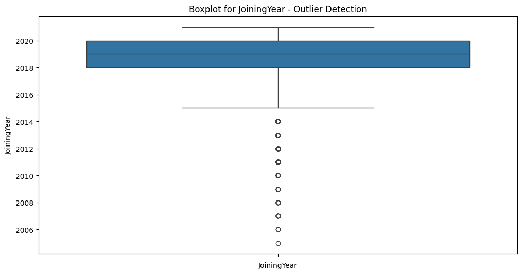

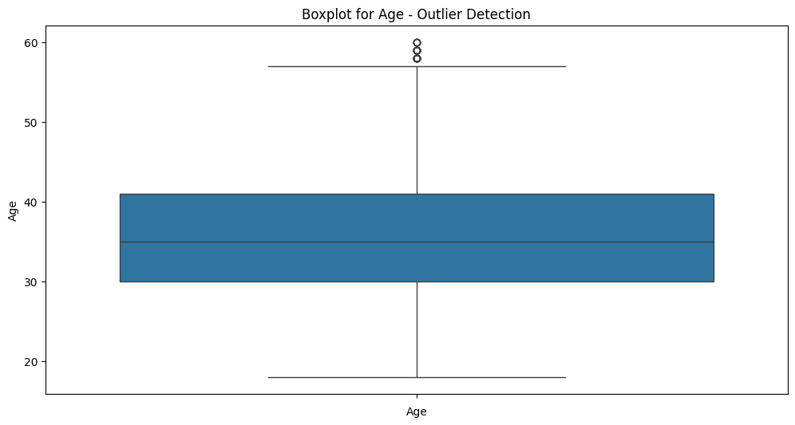

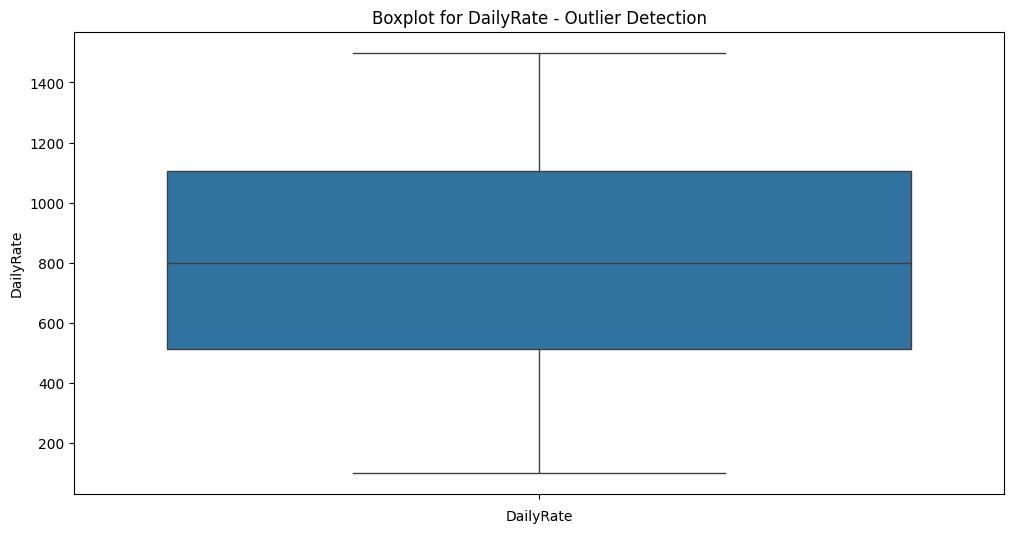

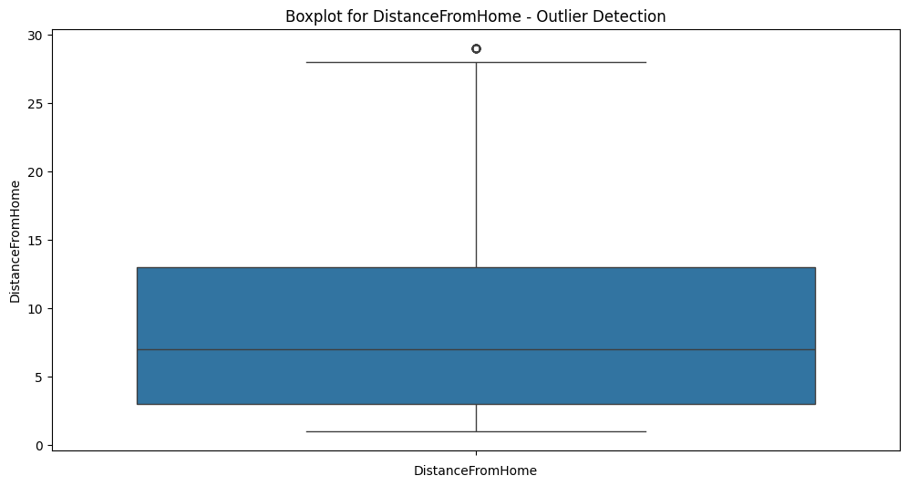

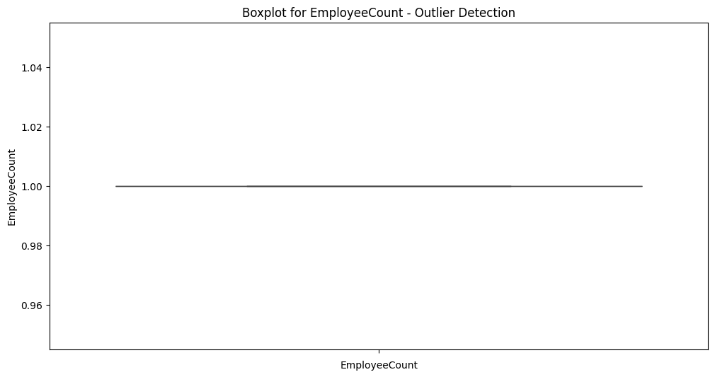

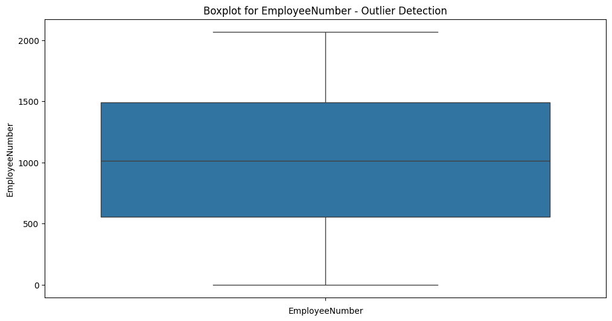

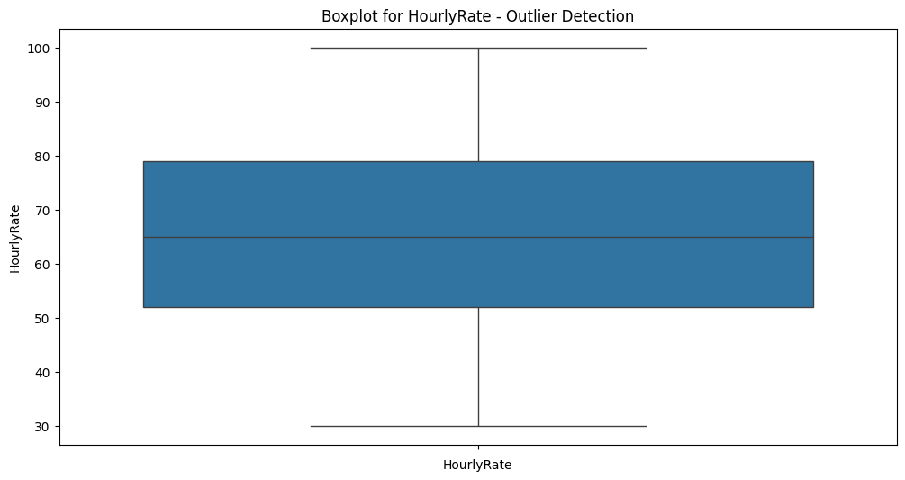

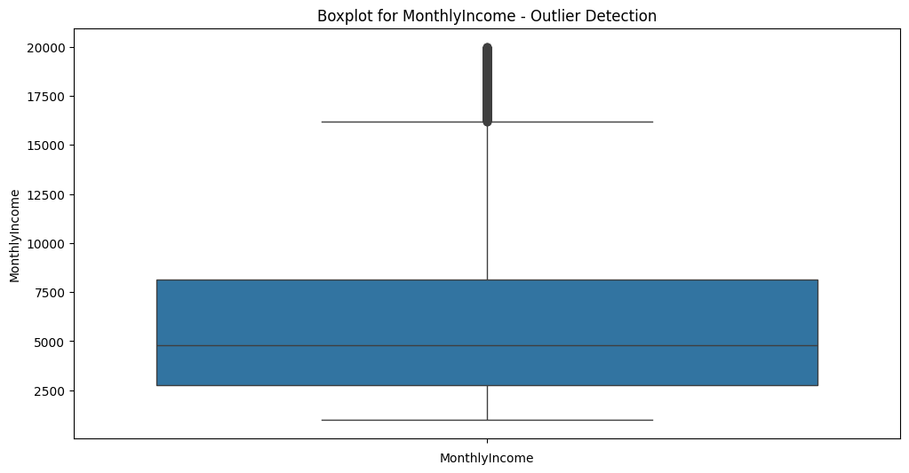

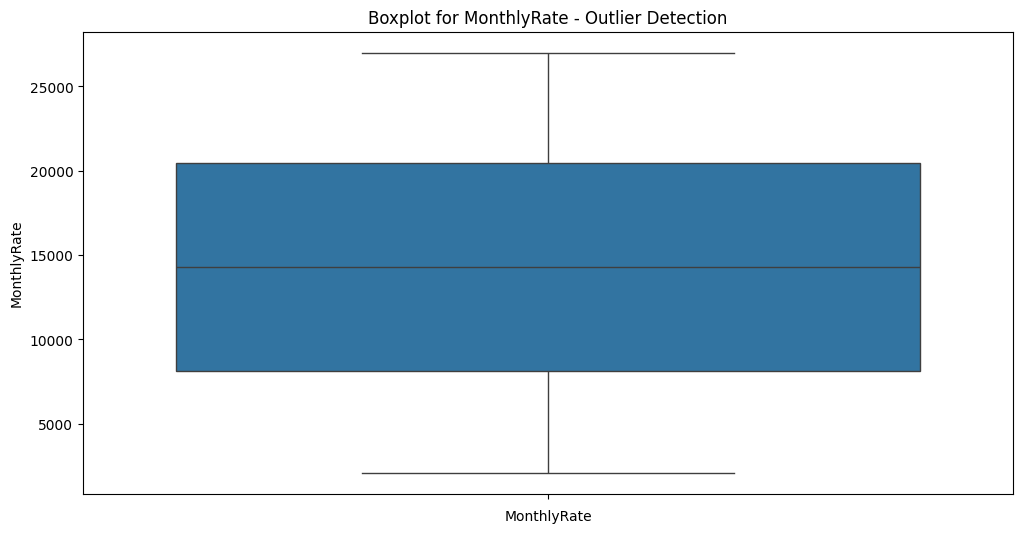

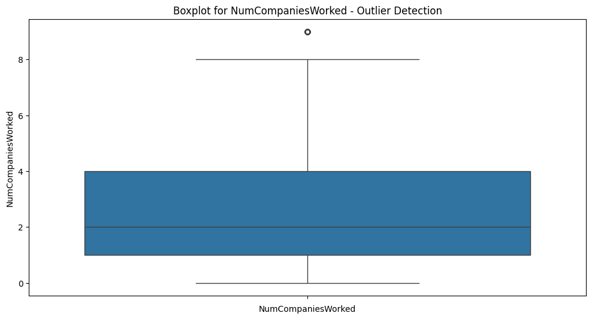

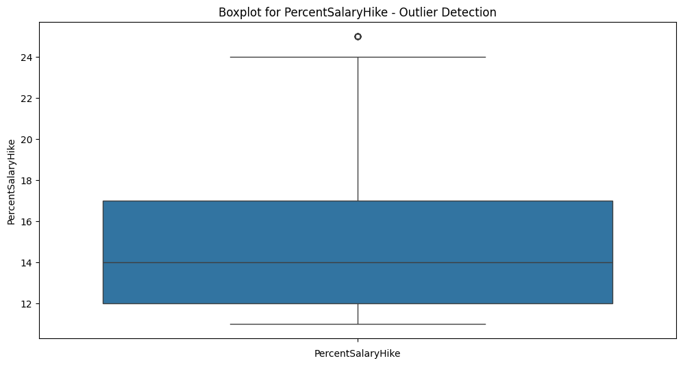

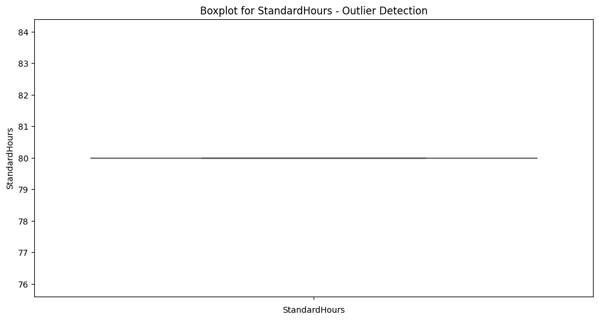

[5 more figures not shown]

```python
dataa = numerical_variables

for d in dataa:
    plt.figure(figsize=(12, 6))
    sns.boxplot(data=df[d])
    plt.title("Boxplots for Outlier Detection")
    plt.title(f"Boxplot for {d} - Outlier Detection")
    plt.xlabel(d)
    plt.show()
```

#### Bar Plot for Categorical Variables

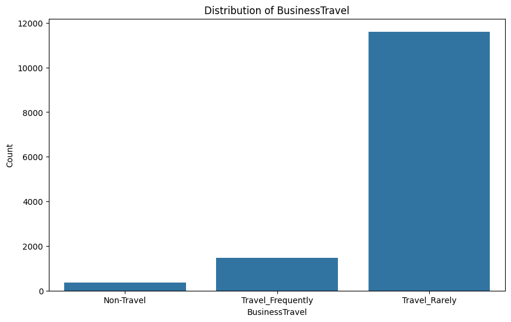

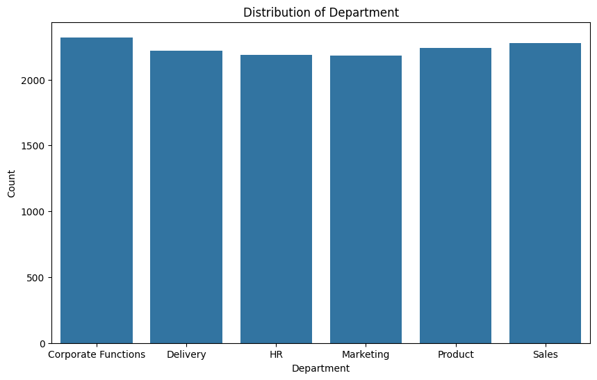

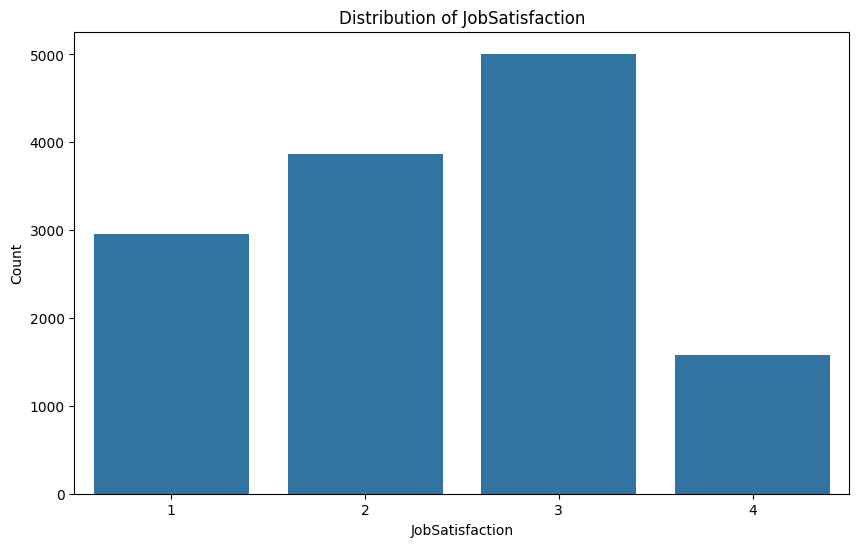

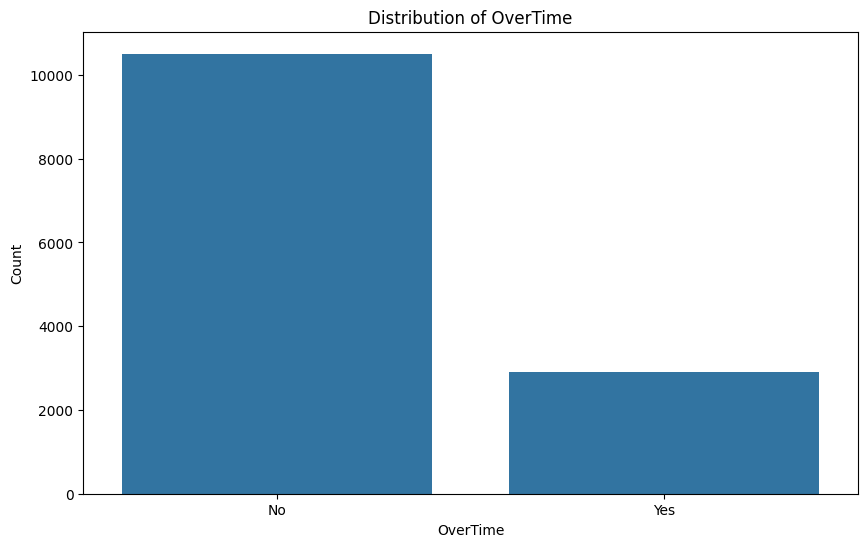

```python
categorical_vars = ['BusinessTravel', 'Department', 'JobSatisfaction', 'OverTime']

for cat in categorical_vars:
    plt.figure(figsize=(10, 6))
    sns.countplot(x=cat, data=df2)
    plt.title(f"Distribution of {cat}")
    plt.ylabel("Count")
    plt.xlabel(cat)
    plt.show()
```

#### Outlier Detection and Removal

The Interquartile Range (IQR) method is used to detect outliers. Outliers are values lying outside 1.5 times the IQR above the third quartile (Q3) or below the first quartile (Q1).

```python
Q1 = df[numerical_variables].quantile(0.25)
Q3 = df[numerical_variables].quantile(0.75)
IQR = Q3 - Q1

outliers = ((df[numerical_variables] < (Q1 - 1.5 * IQR)) | (df[numerical_variables] > (Q3 + 1.5 * IQR))).sum()
print("Number of outliers detected by IQR method:\n ", outliers)
```

```
Number of outliers detected by IQR method:
  JoiningYear                 601
Age                          51
DailyRate                     0
DistanceFromHome             29
EmployeeCount                 0
EmployeeNumber                0
HourlyRate                    0
MonthlyIncome              1045
MonthlyRate                   0
NumCompaniesWorked           79
PercentSalaryHike            18
StandardHours                 0
TotalWorkingYears           573
YearsAtCompany             1682
YearsInCurrentRole            2
YearsSinceLastPromotion    3274
YearsWithCurrManager          0
dtype: int64
```

#### Handling Outliers by Replacing Them with NaN

```python
# Calculate Q1, Q3, and IQR
Q1 = df[numerical_variables].quantile(0.25)
Q3 = df[numerical_variables].quantile(0.75)
IQR = Q3 - Q1

# Define outliers as values below Q1 - 1.5*IQR or above Q3 + 1.5*IQR
outliers_lower = df[numerical_variables] < (Q1 - 1.5 * IQR)
outliers_upper = df[numerical_variables] > (Q3 + 1.5 * IQR)

# Replace outliers with NaN
df[numerical_variables] = df[numerical_variables].mask(outliers_lower | outliers_upper)
```

Outliers identified in the previous step are replaced with NaN. This allows us to later impute these values using suitable techniques.

#### Checking for Missing Values

After handling outliers, we check for missing values to ensure no critical data is missing and to prepare for the imputation process.

```python
df.isnull().sum()
```

```
JoiningYear                   601
Age                            51
BusinessTravel                  0
DailyRate                       0
Department                      0
DistanceFromHome               29
EducationField                  0
EmployeeCount                   0
EmployeeNumber                  0
EnvironmentSatisfaction         0
Gender                          0
HourlyRate                      0
JobInvolvement                  0
JobSatisfaction                 0
MaritalStatus                   0
MonthlyIncome                1045
MonthlyRate                     0
NumCompaniesWorked             79
Over18                          0
OverTime                        0
PercentSalaryHike              18
PerformanceRating               0
RelationshipSatisfaction        0
StandardHours                   0
StockOptionLevel                0
TotalWorkingYears             573
TrainingTimesLastYear           0
WorkLifeBalance                 0
YearsAtCompany               1682
YearsInCurrentRole              2
YearsSinceLastPromotion      3274
YearsWithCurrManager            0
Attrition                       0
LeavingYear                 10225
Reason                      10225
RelievingStatus             10225
office_code                     0
JobLevel_updated                0
dtype: int64
```

| Variable Name | No of Missing Values |
| --- | --- |
| JoiningYear | 601 |
| Age | 51 |
| DistanceFromHome | 29 |
| LeavingYear | 10225 |
| MonthlyIncome | 1045 |
| NumCompaniesWorked | 79 |
| PercentSalaryHike | 18 |
| TotalWorkingYears | 573 |
| YearsAtCompany | 1682 |
| YearsSinceLastPromotion | 3274 |
| Reason | 10225 |
| RelievingStatus | 10225 |

These are my variables. Anyhow my paper have used MissForest to handle missing values. So, I am going to use MissForest to handle categorical variables missing values

```python
cat_var = ['LeavingYear', 'Reason', 'RelievingStatus']

for cat in cat_var:
    print(df[cat].unique())
```

```
[2019.0, 2018.0, 2021.0, 2022.0, 2020.0, NaN]
Categories (5, float64): [2018.0, 2019.0, 2020.0, 2021.0, 2022.0]
['long hours', 'medical issues', 'retiring', 'career change', 'return to school', ..., 'death', 'cost cutting', 'poor work performance', 'Layoffs', 'restructuring']
Length: 16
Categories (15, object): ['Layoffs', 'Misconduct', 'career change', 'cost cutting', ..., 'restructuring', 'retiring', 'return to school', 'unhappy']
['Voluntary', 'Involuntary', NaN]
Categories (2, object): ['Involuntary', 'Voluntary']
```

#### Encoding Categorical Variables

```python
df['LeavingYear'] = df['LeavingYear'].map({2019: 0, 2018: 1, 2021: 2, 2022: 3, 2020: 4})

df['Reason'] = df['Reason'].map({
    'long hours': 0,
    'medical issues': 1,
    'retiring': 2,
    'career change': 3,
    'return to school': 4,
    'Misconduct': 5,
    'offered more money': 6,
    'unhappy': 7,
    'reallocation out of the area': 8,
    'maternity leave - did not return': 9,
    'death': 10,
    'cost cutting': 11,
    'poor work performance': 12,
    'Layoffs': 13,
    'restructuring': 14
})


df['RelievingStatus'] = df['RelievingStatus'].map({'Voluntary': 0, 'Involuntary': 1})
```

Categorical variables are encoded into numerical values. This step is necessary for any machine learning model as they require numerical input.

## **Missing Values Imputation**

#### Imputing Missing Values with MissForest

MissForest is a random forest imputation algorithm for missing data. It initially imputes all missing data using the mean/mode, then for each variable with missing values, MissForest fits a random forest on the observed part and then predicts the missing part. This process of training and predicting repeats in an iterative process until a stopping criterion is met, or a maximum number of user-specified iterations is reached.

We use the MissForest algorithm to impute missing values in both categorical and numerical columns. This method is effective in preserving the data structure during imputation.

```python
df[categorical_variables] = df[categorical_variables].astype('category')
```

```python
imputer_mixed = MissForest()

df2 = imputer_mixed.fit_transform(df, categorical=categorical_variables)
```

```python
df2[categorical_variables] = df2[categorical_variables].astype('category')
```

```python
df2.isnull().sum()
```

```
JoiningYear                 0
Age                         0
BusinessTravel              0
DailyRate                   0
Department                  0
DistanceFromHome            0
EducationField              0
EmployeeCount               0
EmployeeNumber              0
EnvironmentSatisfaction     0
Gender                      0
HourlyRate                  0
JobInvolvement              0
JobSatisfaction             0
MaritalStatus               0
MonthlyIncome               0
MonthlyRate                 0
NumCompaniesWorked          0
Over18                      0
OverTime                    0
PercentSalaryHike           0
PerformanceRating           0
RelationshipSatisfaction    0
StandardHours               0
StockOptionLevel            0
TotalWorkingYears           0
TrainingTimesLastYear       0
WorkLifeBalance             0
YearsAtCompany              0
YearsInCurrentRole          0
YearsSinceLastPromotion     0
YearsWithCurrManager        0
Attrition                   0
LeavingYear                 0
Reason                      0
RelievingStatus             0
office_code                 0
JobLevel_updated            0
dtype: int64
```

```python
df2.shape
```

```
(13423, 38)
```

## **Classification**

#### Encoding Categorical Variables as Dummies

```python
dummyvar= ["BusinessTravel", "Department","EducationField", "EnvironmentSatisfaction", "Gender", "JobInvolvement",
                         "JobSatisfaction", "MaritalStatus", "OverTime", "Over18", "PerformanceRating", "RelationshipSatisfaction",
                         "StockOptionLevel", "TrainingTimesLastYear", "WorkLifeBalance", "LeavingYear", "Reason", "RelievingStatus", "office_code", "JobLevel_updated"]
```

```python
df = pd.get_dummies(df2, columns=dummyvar, prefix=dummyvar, prefix_sep='_', dtype='int')
```

We convert categorical variables into dummy variables (one-hot encoding). This process is essential for categorical features in machine learning models.

```python
df.shape
```

```
(13423, 112)
```

```python
df['Attrition'] = df['Attrition'].map({'Yes': 0, 'No': 1})
```

#### Scaling Numerical Features

Features are scaled using **StandardScaler** to ensure that all variables contribute equally to the model's performance, avoiding any dominance due to different scales.

```python
X = df.drop('Attrition', axis = 1)
y = df['Attrition']
```

```python
scaler = StandardScaler()
X = scaler.fit_transform(X)
```

Multiple models are trained and evaluated using cross-validation. The performance of each model is assessed using metrics like accuracy, classification report, and confusion matrix.

#### Data Splitting: Separating Training and Test Sets

Below step splits the dataset into training and test sets, with 80% of the data used for training and 20% for testing, ensuring reproducibility with a fixed random state.

```python
X_train, X_test, y_train, y_test = train_test_split(X, y, test_size=0.2, random_state=42)
```

#### 1. Decision Tree Classifier

A model that uses a tree-like structure of decisions and their possible consequences. It splits the data into branches based on feature values, leading to a final decision (classification or regression).

```python
dt_classifier = DecisionTreeClassifier()
dt_classifier.fit(X_train, y_train)
```

```
DecisionTreeClassifier()
```

```python
k = 10
kf = KFold(n_splits=k, shuffle=True, random_state=42)
```

```python
scores = cross_val_score(dt_classifier, X_train, y_train, cv=kf)
print(f'Cross-Validation Results (Accuracy): {scores}')
print(f'Mean Accuracy: {scores.mean()}')
```

```
Cross-Validation Results (Accuracy): [0.9972067  0.9972067  0.99534451 0.99441341 1.         0.9981378
 0.9972067  0.99627561 0.99627213 0.99534017]
Mean Accuracy: 0.9967403735849121
```

#### 2. Random Forest Classifier

A Random Forest is an ensemble learning method that combines multiple decision trees to improve the model's accuracy and robustness. Each tree is trained on a random subset of the data and features, and the final prediction is made by averaging the predictions of all trees (for regression) or by majority vote (for classification).

```python
random_forest_classifier = RandomForestClassifier()
random_forest_classifier.fit(X_train, y_train)
```

```
RandomForestClassifier()
```

```python
scores = cross_val_score(random_forest_classifier,X_train, y_train, cv=kf)
print(f'Cross-Validation Results (Accuracy): {scores}')
print(f'Mean Accuracy: {scores.mean()}')
```

```
Cross-Validation Results (Accuracy): [0.9981378  0.9990689  0.9972067  0.9981378  1.         0.9981378
 1.         0.99627561 0.99906803 0.99627213]
Mean Accuracy: 0.9982304786003494
```

These results suggest that the Random Forest model is performing exceptionally well, with strong generalization capabilities across different subsets of the training data. The minimal variance in accuracy scores also indicates that the model is stable and reliable, with little risk of overfitting. Overall, the Random Forest classifier appears to be an excellent choice for this classification task, offering both high accuracy and consistent performance.

#### 3. K-Nearest Neighbors (KNN) Classifier

A simple, non-parametric algorithm used for classification and regression. It classifies a data point based on how its neighbors are classified, making predictions by majority voting among the nearest neighbors.

```python
knn = KNeighborsClassifier()
knn.fit(X_train, y_train)
```

```
KNeighborsClassifier()
```

```python
k = 5
kf = KFold(n_splits=k, shuffle=True, random_state=42)
scores = cross_val_score(knn, X_train, y_train, cv=kf)
print(f'Cross-Validation Results (Accuracy): {scores}')
print(f'Mean Accuracy: {scores.mean()}')
```

```
Cross-Validation Results (Accuracy): [0.97765363 0.98649907 0.98184358 0.98602701 0.98369818]
Mean Accuracy: 0.9831442947111686
```

The cross-validation results for the K-Nearest Neighbors (KNN) classifier show strong accuracy across the 5 folds, with accuracy scores ranging from 0.9777 to 0.9865. The mean accuracy across all folds is approximately 0.9831, indicating that the KNN model accurately predicts the target variable around 98.31% of the time.

These results suggest that the KNN classifier is performing well, with high accuracy in most of the training data subsets. While the accuracy is slightly lower than the results observed with the Random Forest classifier, it still demonstrates that KNN is a reliable model for this classification task.The scores indicate that the model has good generalization capabilities and can make accurate predictions on unseen data.However, the slight variability in the accuracy scores suggests that KNN might be somewhat sensitive to the specific folds of data used, potentially reflecting the influence of nearby data points on the model's predictions. Overall, KNN offers a strong and consistent performance, making it a viable option for classification in this context.

#### 4. XGBoost Classifier

XGBoost is a powerful, scalable machine learning algorithm that uses the gradient boosting framework. It builds an ensemble of weak learners (typically decision trees) sequentially, where each new tree attempts to correct the errors made by the previous trees. XGBoost is known for its high performance and efficiency in handling large datasets.

```python
xg_classifier = XGBClassifier()

xg_classifier.fit(X_train, y_train)
```

```
XGBClassifier(base_score=None, booster=None, callbacks=None,
              colsample_bylevel=None, colsample_bynode=None,
              colsample_bytree=None, device=None, early_stopping_rounds=None,
              enable_categorical=False, eval_metric=None, feature_types=None,
              gamma=None, grow_policy=None, importance_type=None,
              interaction_constraints=None, learning_rate=None, max_bin=None,
              max_cat_threshold=None, max_cat_to_onehot=None,
              max_delta_step=None, max_depth=None, max_leaves=None,
              min_child_weight=None, missing=nan, monotone_constraints=None,
              multi_strategy=None, n_estimators=None, n_jobs=None,
              num_parallel_tree=None, random_state=None, ...)
```

```python
scores = cross_val_score(xg_classifier, X, y, cv=kf)
print(f'Cross-Validation Results (Accuracy): {scores}')
print(f'Mean Accuracy: {scores.mean()}')
```

```
Cross-Validation Results (Accuracy): [0.9981378  0.99739292 0.99664804 0.99888227 0.99850969]
Mean Accuracy: 0.9979141446519411
```

#### Fit and Prediction

```python
model = [dt_classifier, random_forest_classifier, knn, xg_classifier]

for m in model:
    m.fit(X_train, y_train)
    y_pred = m.predict(X_test)
    print(f"\n{m} Performance:")
    print(f"Accuracy: {accuracy_score(y_test, y_pred):.4f}")
    print("Classification Report:")
    print(classification_report(y_test, y_pred))
    print("Confusion Matrix:")
    print(confusion_matrix(y_test, y_pred))
```

```
DecisionTreeClassifier() Performance:
Accuracy: 0.9952
Classification Report:
              precision    recall  f1-score   support

           0       0.99      0.99      0.99       647
           1       1.00      1.00      1.00      2038

    accuracy                           1.00      2685
   macro avg       0.99      0.99      0.99      2685
weighted avg       1.00      1.00      1.00      2685

Confusion Matrix:
[[ 641    6]
 [   7 2031]]

RandomForestClassifier() Performance:
Accuracy: 0.9989
Classification Report:
              precision    recall  f1-score   support

           0       1.00      1.00      1.00       647
           1       1.00      1.00      1.00      2038

    accuracy                           1.00      2685
   macro avg       1.00      1.00      1.00      2685
weighted avg       1.00      1.00      1.00      2685

Confusion Matrix:
[[ 644    3]
 [   0 2038]]

KNeighborsClassifier() Performance:
Accuracy: 0.9866
Classification Report:
              precision    recall  f1-score   support

           0       1.00      0.94      0.97       647
           1       0.98      1.00      0.99      2038

```

[output cut: 18 more lines]

```
              num_parallel_tree=None, random_state=None, ...) Performance:
Accuracy: 0.9981
Classification Report:
              precision    recall  f1-score   support

           0       1.00      0.99      1.00       647
           1       1.00      1.00      1.00      2038

    accuracy                           1.00      2685
   macro avg       1.00      1.00      1.00      2685
weighted avg       1.00      1.00      1.00      2685

Confusion Matrix:
[[ 643    4]
 [   1 2037]]
```

**Decision Tree Classifier**  
The Decision Tree Classifier correctly predicted 99.52% of the cases in the test data. It did a great job with both classes, almost perfectly identifying them. It made a few mistakes: 6 times it confused class 0 with class 1 and 7 times it confused class 1 with class 0. Overall, it's very accurate but slightly less so compared to some other models.

**Random Forest Classifier**  
The Random Forest Classifier was the most accurate, with 99.89% correct predictions. It did an excellent job with both classes, making no mistakes in predicting class 1 and only confusing 3 class 0 cases as class 1. This model is very reliable and handles the data well, thanks to its combination of multiple decision trees.

**KNN Classifier**  
The K-Nearest Neighbors (KNN) Classifier had an accuracy of 98.66%. It performed well but was not as precise with class 0 as the other models, misclassifying 36 class 0 cases as class 1. While it did a good job with class 1, it made more errors with class 0 compared to the other models.

**XGBoost Classifier**  
The XGBoost Classifier achieved 99.81% accuracy. It performed very well, making only 4 mistakes with class 0 and 1 mistake with class 1. It handled the data effectively and had high accuracy with both classes, showing that it’s a strong model for this task.

## **Conclusion**

[output not shown]

In the research for predicting the best employee using machine learning algorithms, the **Random Forest Classifier** stands out as the most effective model. It achieved a remarkable accuracy of 99.82% on the training data and 99.89% on the test data. This high accuracy demonstrates the model's exceptional performance in identifying top candidates and its strong ability to generalize from training to new, unseen data. The Random Forest Classifier’s robust performance and consistency make it the best choice for this prediction task, ensuring reliable and precise identification of the best employees.

### **References**

https://www.geeksforgeeks.org/cross-validation-machine-learning/  
https://www.geeksforgeeks.org/xgboost/  
Dataset: https://www.kaggle.com/datasets/jash312/hr-employee-attrition-datasets?select=HR+Employee+data.csv  
Research Paper: https://ijconsist.org/index.php/ijconsist/article/view/43/35